# Machine_Learning - Project -

Mike McLaughlin

January 29, 2017

### Overview

The purpose of this assignment is to review data provided related to weight lifting and the results. The data was downloaded from these sites.

https://d396qusza40orc.cloudfront.net/predmachlearn/pml-training.csv

https://d396qusza40orc.cloudfront.net/predmachlearn/pml-testing.csv

The objective is to determine a good model to use to predict the best outcome. Participants were asked to lifted weights using various techniques. Some techniques were considered correct and some were considered incorrect. By using data from tracking devices on the belt, forearm, arm, and dumbbell we aim to predict the observation class.

Background on the data can be found at the below site.

http://groupware.les.inf.puc-rio.br/har

Is that also been requested to cite the below if using the data.

Velloso, E.; Bulling, A.; Gellersen, H.; Ugulino, W.; Fuks, H. Qualitative Activity Recognition of Weight Lifting Exercises. Proceedings of 4th International Conference in Cooperation with SIGCHI (Augmented Human ’13) . Stuttgart, Germany: ACM SIGCHI, 2013.

Read more: http://groupware.les.inf.puc-rio.br/har#ixzz4XAg7Neec

#### Get Data

Download data and insure directory exsists.

```r
 #Insure directory for class is available.
  rwd <- "C:/2016/Mike_Classes/Machine_Learning/Class_Project"
  #If directory is not available create directory.
  if(!file.exists(rwd)){dir.create(rwd)}
  #Set working directory.
  setwd(rwd)
  #Create a variable with the directory to download files.
  assignData <- "./Data"
  #Check that if directory exists.   If not create directory.
  if(!file.exists(assignData)){dir.create(assignData)}
  #Retrieve files and unzip into working directory.
  url1 <- "https://d396qusza40orc.cloudfront.net/predmachlearn/pml-training.csv"
  url2 <- "https://d396qusza40orc.cloudfront.net/predmachlearn/pml-testing.csv"
  filename1 <- paste(assignData,"/","pml-training.csv", sep="")
  filename2 <- paste(assignData,"/","pml-testing.csv", sep="")
    download.file(url1,filename1)
    download.file(url2,filename2)

    x_train <- read.table(filename1, sep=",",header=TRUE)
    y_test <- read.table(filename2, sep=",",head=TRUE)
```

### Review and Setup Data

The data appears to have columns with all “NA” or over half the rows are “NA” I am going to remove those columns to have a data set that includes data in most rows and columns.

```r
   zeroValueTraining <- nearZeroVar(x_train, saveMetrics=TRUE)
    trainingSub <- x_train[,zeroValueTraining$nzv==FALSE]

    trainingSub <- trainingSub[,7:length(colnames(trainingSub))]

    # Count NA in each column
    nonnaCols <- as.vector(apply(trainingSub, 2, function(trainingSub) length(which(!is.na(trainingSub)))))

    # remove columns that have more than 50% NAs
    dropNAs <- c()
    for (i in 1:length(nonnaCols)) {
      if (nonnaCols[i] > nrow(trainingSub)*.50) {
        dropNAs <- c(dropNAs, colnames(trainingSub)[i])
      }
    }

    #remove NA data in training and testing
    trainingSub <- trainingSub[,(names(trainingSub) %in% dropNAs)]

    keepCols <- colnames(trainingSub[, -53]) #remove classe as it's not contained in testing
    testingSub <- y_test[keepCols] #keep only variables in testing
    dim(trainingSub)
```

```
## [1] 19622    53
```

```r
    dim(testingSub)
```

```
## [1] 20 52
```

### Create second testing set for cross validation

As the included testing data is a very small sample, I am going to split the original training set into a training and second testing set using a 60/40 split. This will allow me to test my model on a much larger set of data, which hopefully will provided a more accurate model.

```r
   set.seed(254)
    sTS <- createDataPartition(trainingSub$classe, p=.6 , list=FALSE)
    trainingSub1 <- trainingSub[sTS,]
    trainTest2 <- trainingSub[-sTS,]
    dim(trainingSub1)
```

```
## [1] 11776    53
```

```r
    dim(trainTest2)
```

```
## [1] 7846   53
```

### First Test using RPART/Decision Tree

This is a very fast and visual test. I will use this as a first attempt.

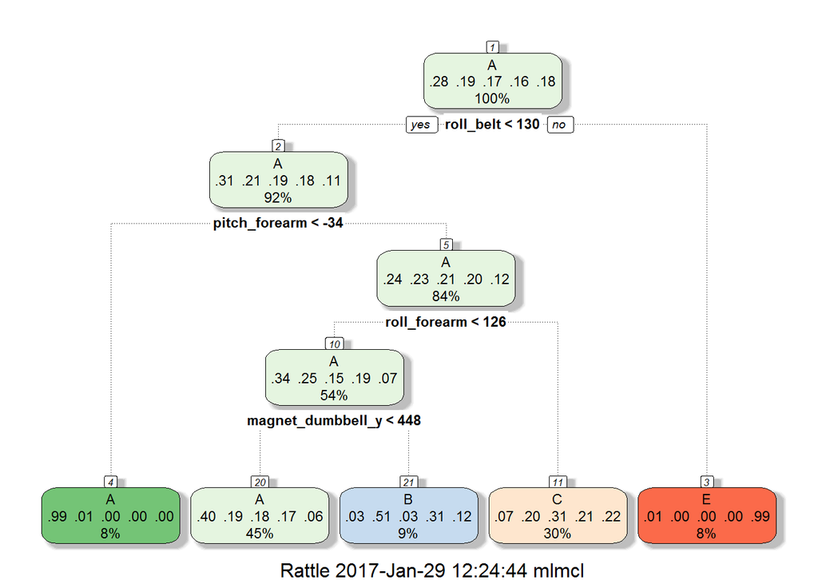

```r
    modFit1 <- train(classe ~ .,method="rpart",data=trainingSub1)
    fancyRpartPlot(modFit1$finalModel)
```

```r
    predict1 <- predict(modFit1, newdata=trainingSub1)
    confusionMatrix(predict1, trainingSub1$classe)
```

```
## Confusion Matrix and Statistics
##
##           Reference
## Prediction    A    B    C    D    E
##          A 3070 1044  953  893  334
##          B   28  532   32  322  120
##          C  239  703 1069  715  758
##          D    0    0    0    0    0
##          E   11    0    0    0  953
##
## Overall Statistics
##
##                Accuracy : 0.4776
##                  95% CI : (0.4685, 0.4867)
##     No Information Rate : 0.2843
##     P-Value [Acc > NIR] : < 2.2e-16
##
##                   Kappa : 0.3166
##  Mcnemar's Test P-Value : NA
##
## Statistics by Class:
##
##                      Class: A Class: B Class: C Class: D Class: E
## Sensitivity            0.9170  0.23344  0.52045   0.0000  0.44018
## Specificity            0.6175  0.94714  0.75159   1.0000  0.99886
## Pos Pred Value         0.4878  0.51451  0.30683      NaN  0.98859
## Neg Pred Value         0.9493  0.83737  0.88121   0.8361  0.88790
## Prevalence             0.2843  0.19353  0.17442   0.1639  0.18385
## Detection Rate         0.2607  0.04518  0.09078   0.0000  0.08093
## Detection Prevalence   0.5345  0.08781  0.29586   0.0000  0.08186
## Balanced Accuracy      0.7672  0.59029  0.63602   0.5000  0.71952
```

This test worked quicky and created a nice graphic. However, the accuracy rate of about 48% is not acceptable.

### Second test using Random Forest

This test will take much longer, but hopefully will provide a higher level of Accuracy.

```r
  #modFit2 <- train(trainingSub1$classe ~ ., method="rf", preProcess=c("center", "scale"), trControl=trainControl(method = "cv", number = 4), data=trainingSub1)
    modFit2 <- train(classe ~ ., method="rf",trControl=trainControl(method = "cv", number = 4), data=trainingSub1)
    predict2 <- predict(modFit2,trainingSub1)
    confusionMatrix(predict2, trainingSub1$classe)
```

```
## Confusion Matrix and Statistics
##
##           Reference
## Prediction    A    B    C    D    E
##          A 3348    0    0    0    0
##          B    0 2279    0    0    0
##          C    0    0 2054    0    0
##          D    0    0    0 1930    0
##          E    0    0    0    0 2165
##
## Overall Statistics
##
##                Accuracy : 1
##                  95% CI : (0.9997, 1)
##     No Information Rate : 0.2843
##     P-Value [Acc > NIR] : < 2.2e-16
##
##                   Kappa : 1
##  Mcnemar's Test P-Value : NA
##
## Statistics by Class:
##
##                      Class: A Class: B Class: C Class: D Class: E
## Sensitivity            1.0000   1.0000   1.0000   1.0000   1.0000
## Specificity            1.0000   1.0000   1.0000   1.0000   1.0000
## Pos Pred Value         1.0000   1.0000   1.0000   1.0000   1.0000
## Neg Pred Value         1.0000   1.0000   1.0000   1.0000   1.0000
## Prevalence             0.2843   0.1935   0.1744   0.1639   0.1838
## Detection Rate         0.2843   0.1935   0.1744   0.1639   0.1838
## Detection Prevalence   0.2843   0.1935   0.1744   0.1639   0.1838
## Balanced Accuracy      1.0000   1.0000   1.0000   1.0000   1.0000
```

```r
    print(modFit2, digits=3)
```

```
## Random Forest
##
## 11776 samples
##    52 predictor
##     5 classes: 'A', 'B', 'C', 'D', 'E'
##
## No pre-processing
## Resampling: Cross-Validated (4 fold)
## Summary of sample sizes: 8833, 8831, 8832, 8832
## Resampling results across tuning parameters:
##
##   mtry  Accuracy  Kappa
##    2    0.988     0.985
##   27    0.987     0.983
##   52    0.980     0.975
##
## Accuracy was used to select the optimal model using  the largest value.
## The final value used for the model was mtry = 2.
```

This test has produced 100% accuracy which may suggest an overfitted model. I will test this model on the test set that was created from the original training test. As you recall, this had about 7800 records to test.

```r
   predict3 <- predict(modFit2,trainTest2)
  confusionMatrix(predict3, trainTest2$classe)
```

```
## Confusion Matrix and Statistics
##
##           Reference
## Prediction    A    B    C    D    E
##          A 2230    9    0    0    0
##          B    2 1508   23    0    0
##          C    0    1 1344   21    1
##          D    0    0    1 1263    1
##          E    0    0    0    2 1440
##
## Overall Statistics
##
##                Accuracy : 0.9922
##                  95% CI : (0.99, 0.994)
##     No Information Rate : 0.2845
##     P-Value [Acc > NIR] : < 2.2e-16
##
##                   Kappa : 0.9902
##  Mcnemar's Test P-Value : NA
##
## Statistics by Class:
##
##                      Class: A Class: B Class: C Class: D Class: E
## Sensitivity            0.9991   0.9934   0.9825   0.9821   0.9986
## Specificity            0.9984   0.9960   0.9964   0.9997   0.9997
## Pos Pred Value         0.9960   0.9837   0.9832   0.9984   0.9986
## Neg Pred Value         0.9996   0.9984   0.9963   0.9965   0.9997
## Prevalence             0.2845   0.1935   0.1744   0.1639   0.1838
## Detection Rate         0.2842   0.1922   0.1713   0.1610   0.1835
## Detection Prevalence   0.2854   0.1954   0.1742   0.1612   0.1838
## Balanced Accuracy      0.9988   0.9947   0.9895   0.9909   0.9992
```

A 99% accuracy rate. Since it is not much beyond 99% is will use this model. However, I will test other methods offline to get a sense of how they compare.

```r
predict3 <- predict(modFit2,trainTest2)
    confusionMatrix(predict3, trainTest2$classe)
```

[output not shown]

```r
    predictTesting <- predict(modFit2, newdata=y_test)
    predictTesting
```

```
##  [1] B A B A A E D B A A B C B A E E A B B B
## Levels: A B C D E
```

### Conclusions

The Decision Tree method is much faster with less accuracy. The random forest method provides a much higher level of accuracy. However, it is very slow. One potential conclusion from the data is that accurate processes will be easier to predict when compared with inaccurate process.